# analysis slides

## Which Feature of This Dataset Best Describes the Sale Price?

### I'll start by using Pandas to convert the CSV file into a Dataframe.

```python
#load in dataset
df = pd.read_csv('dataset.csv')
df.head()
```

|  | Id | MSSubClass | MSZoning | LotFrontage | LotArea | Street | Alley | LotShape | LandContour | Utilities | LotConfig | LandSlope | Neighborhood | Condition1 | Condition2 | BldgType | HouseStyle | OverallQual | OverallCond | YearBuilt | YearRemodAdd | RoofStyle | RoofMatl | Exterior1st | Exterior2nd | MasVnrType | MasVnrArea | ExterQual | ExterCond | … |
| --- | --- | --- | --- | --- | --- | --- | --- | --- | --- | --- | --- | --- | --- | --- | --- | --- | --- | --- | --- | --- | --- | --- | --- | --- | --- | --- | --- | --- | --- | --- |
| 0 | 1 | 60 | RL | 65.0 | 8450 | Pave | NaN | Reg | Lvl | AllPub | Inside | Gtl | CollgCr | Norm | Norm | 1Fam | 2Story | 7 | 5 | 2003 | 2003 | Gable | CompShg | VinylSd | VinylSd | BrkFace | 196.0 | Gd | TA | … |
| 1 | 2 | 20 | RL | 80.0 | 9600 | Pave | NaN | Reg | Lvl | AllPub | FR2 | Gtl | Veenker | Feedr | Norm | 1Fam | 1Story | 6 | 8 | 1976 | 1976 | Gable | CompShg | MetalSd | MetalSd | None | 0.0 | TA | TA | … |
| 2 | 3 | 60 | RL | 68.0 | 11250 | Pave | NaN | IR1 | Lvl | AllPub | Inside | Gtl | CollgCr | Norm | Norm | 1Fam | 2Story | 7 | 5 | 2001 | 2002 | Gable | CompShg | VinylSd | VinylSd | BrkFace | 162.0 | Gd | TA | … |
| 3 | 4 | 70 | RL | 60.0 | 9550 | Pave | NaN | IR1 | Lvl | AllPub | Corner | Gtl | Crawfor | Norm | Norm | 1Fam | 2Story | 7 | 5 | 1915 | 1970 | Gable | CompShg | Wd Sdng | Wd Shng | None | 0.0 | TA | TA | … |
| 4 | 5 | 60 | RL | 84.0 | 14260 | Pave | NaN | IR1 | Lvl | AllPub | FR2 | Gtl | NoRidge | Norm | Norm | 1Fam | 2Story | 8 | 5 | 2000 | 2000 | Gable | CompShg | VinylSd | VinylSd | BrkFace | 350.0 | Gd | TA | … |

```python
#get datatypes for each column
df.info()
```

[output not shown]

[output cut: 26 more lines]

```
PavedDrive       1460 non-null object
WoodDeckSF       1460 non-null int64
OpenPorchSF      1460 non-null int64
EnclosedPorch    1460 non-null int64
3SsnPorch        1460 non-null int64
ScreenPorch      1460 non-null int64
PoolArea         1460 non-null int64
MiscVal          1460 non-null int64
MoSold           1460 non-null int64
YrSold           1460 non-null int64
SaleType         1460 non-null object
SaleCondition    1460 non-null object
SalePrice        1460 non-null int64
dtypes: float64(2), int64(34), object(40)
memory usage: 867.0+ KB
```

**This dataset has a mix of datatypes including floats, integers, and objects (which represent strings).**

## Data Cleaning and Manipulation

#### I've decided to drop the features with too few values since they won't be the best source of information.

I'm using pandas .drop() function to access these specific columns and drop them while still keeping the same number of rows.

```python
df = df.drop(['PoolQC', 'Alley', 'Fence', 'MiscFeature'], axis=1)
```

#### Breakdown of columns with NaN values

- LotFrontage = linear feet of street connected to property. (These NaN values could be due to properties with no lot frontage as opposed to errors or missing information)
- MasVnrType, MasVnrArea = Homes that have mason veneers and the area in square feet. (These NaN values represent properties that don't have mason veneers, it is not due to an error)
- BsmtQual, BsmtCond, BsmtExposure, BsmtFinType1, BsmtFinType2 = These columns describe various aspects of the basement in these units. (According to the data description, NA symbolizes the homes without basements. Therefore we know these aren't due to errors)
- Electrical = type of electrical system in property. (There is only one NaN value probably due to a small error or missing information
- FireplaceQu = quality of fireplace (NaN values can be attributed to homes without a fireplace. This is not due to errors)
- GarageType, GarageYrBlt, GarageFinish, GarageCars, GarageArea, GarageQual, GarageCond = descriptive information about properties with garages (NaN values represent homes with no garages)

**I've concluded that all the NaN values, excluding the Electrical column, are mostly valid and due to some properties having certain features that others don't.**

I am going to handle the mason veneer type and the mason veneer area featueres separately since one is a string object and the other is a float. I'm going to replace the type with NoMV (no mason veneer) and the area with the value 0.0

```python
df['MasVnrType'].fillna('NoMV', inplace = True)
df['MasVnrArea'].fillna(0.0, inplace = True)
```

```python
#checking for null values
df[['MasVnrType', 'MasVnrArea']].isnull().sum()
```

```
MasVnrType    0
MasVnrArea    0
dtype: int64
```

## Data Exploration

For example, the average sale price is 180,921 The minimum sale price found is 34,900 and the maximum sale price is 755,000.

The oldest property listed was built in 1872 and the newest property was built in 2010. Some properties haven't been remodeled since 1950 and were remodeled a lot sooner in 2010.

All of these factors could potentially affect the sales price so it is good to be able to access all of this data.

```python
num_df.describe().T
```

|  | count | mean | std | min | 25% | 50% | 75% | max |
| --- | --- | --- | --- | --- | --- | --- | --- | --- |
| MSSubClass | 1460.0 | 56.897260 | 42.300571 | 20.0 | 20.00 | 50.0 | 70.00 | 190.0 |
| LotFrontage | 1460.0 | 57.623288 | 34.664304 | 0.0 | 42.00 | 63.0 | 79.00 | 313.0 |
| LotArea | 1460.0 | 10516.828082 | 9981.264932 | 1300.0 | 7553.50 | 9478.5 | 11601.50 | 215245.0 |
| OverallQual | 1460.0 | 6.099315 | 1.382997 | 1.0 | 5.00 | 6.0 | 7.00 | 10.0 |
| OverallCond | 1460.0 | 5.575342 | 1.112799 | 1.0 | 5.00 | 5.0 | 6.00 | 9.0 |
| YearBuilt | 1460.0 | 1971.267808 | 30.202904 | 1872.0 | 1954.00 | 1973.0 | 2000.00 | 2010.0 |
| YearRemodAdd | 1460.0 | 1984.865753 | 20.645407 | 1950.0 | 1967.00 | 1994.0 | 2004.00 | 2010.0 |
| MasVnrArea | 1460.0 | 103.117123 | 180.731373 | 0.0 | 0.00 | 0.0 | 164.25 | 1600.0 |
| BsmtFinSF1 | 1460.0 | 443.639726 | 456.098091 | 0.0 | 0.00 | 383.5 | 712.25 | 5644.0 |
| BsmtFinSF2 | 1460.0 | 46.549315 | 161.319273 | 0.0 | 0.00 | 0.0 | 0.00 | 1474.0 |
| BsmtUnfSF | 1460.0 | 567.240411 | 441.866955 | 0.0 | 223.00 | 477.5 | 808.00 | 2336.0 |
| TotalBsmtSF | 1460.0 | 1057.429452 | 438.705324 | 0.0 | 795.75 | 991.5 | 1298.25 | 6110.0 |
| 1stFlrSF | 1460.0 | 1162.626712 | 386.587738 | 334.0 | 882.00 | 1087.0 | 1391.25 | 4692.0 |
| 2ndFlrSF | 1460.0 | 346.992466 | 436.528436 | 0.0 | 0.00 | 0.0 | 728.00 | 2065.0 |
| LowQualFinSF | 1460.0 | 5.844521 | 48.623081 | 0.0 | 0.00 | 0.0 | 0.00 | 572.0 |
| GrLivArea | 1460.0 | 1515.463699 | 525.480383 | 334.0 | 1129.50 | 1464.0 | 1776.75 | 5642.0 |
| BsmtFullBath | 1460.0 | 0.425342 | 0.518911 | 0.0 | 0.00 | 0.0 | 1.00 | 3.0 |
| BsmtHalfBath | 1460.0 | 0.057534 | 0.238753 | 0.0 | 0.00 | 0.0 | 0.00 | 2.0 |
| FullBath | 1460.0 | 1.565068 | 0.550916 | 0.0 | 1.00 | 2.0 | 2.00 | 3.0 |
| HalfBath | 1460.0 | 0.382877 | 0.502885 | 0.0 | 0.00 | 0.0 | 1.00 | 2.0 |
| BedroomAbvGr | 1460.0 | 2.866438 | 0.815778 | 0.0 | 2.00 | 3.0 | 3.00 | 8.0 |
| KitchenAbvGr | 1460.0 | 1.046575 | 0.220338 | 0.0 | 1.00 | 1.0 | 1.00 | 3.0 |
| TotRmsAbvGrd | 1460.0 | 6.517808 | 1.625393 | 2.0 | 5.00 | 6.0 | 7.00 | 14.0 |
| Fireplaces | 1460.0 | 0.613014 | 0.644666 | 0.0 | 0.00 | 1.0 | 1.00 | 3.0 |
| GarageCars | 1460.0 | 1.767123 | 0.747315 | 0.0 | 1.00 | 2.0 | 2.00 | 4.0 |
| GarageArea | 1460.0 | 472.980137 | 213.804841 | 0.0 | 334.50 | 480.0 | 576.00 | 1418.0 |
| WoodDeckSF | 1460.0 | 94.244521 | 125.338794 | 0.0 | 0.00 | 0.0 | 168.00 | 857.0 |
| OpenPorchSF | 1460.0 | 46.660274 | 66.256028 | 0.0 | 0.00 | 25.0 | 68.00 | 547.0 |
| EnclosedPorch | 1460.0 | 21.954110 | 61.119149 | 0.0 | 0.00 | 0.0 | 0.00 | 552.0 |
| 3SsnPorch | 1460.0 | 3.409589 | 29.317331 | 0.0 | 0.00 | 0.0 | 0.00 | 508.0 |
| ScreenPorch | 1460.0 | 15.060959 | 55.757415 | 0.0 | 0.00 | 0.0 | 0.00 | 480.0 |
| PoolArea | 1460.0 | 2.758904 | 40.177307 | 0.0 | 0.00 | 0.0 | 0.00 | 738.0 |
| MiscVal | 1460.0 | 43.489041 | 496.123024 | 0.0 | 0.00 | 0.0 | 0.00 | 15500.0 |
| MoSold | 1460.0 | 6.321918 | 2.703626 | 1.0 | 5.00 | 6.0 | 8.00 | 12.0 |
| YrSold | 1460.0 | 2007.815753 | 1.328095 | 2006.0 | 2007.00 | 2008.0 | 2009.00 | 2010.0 |
| SalePrice | 1460.0 | 180921.195890 | 79442.502883 | 34900.0 | 129975.00 | 163000.0 | 214000.00 | 755000.0 |

### Frequency Distribution of Sale Price

Below, I used seaborn to plot a histogram as well as a kernel density estimation plot to get a feel for how the sale price values are distributed.

Based upon these visualizations, it appears that our sales price is positively skewed to the right with most of the values on the lower end and a few values that are much higher than the others which is expected for this type of data.

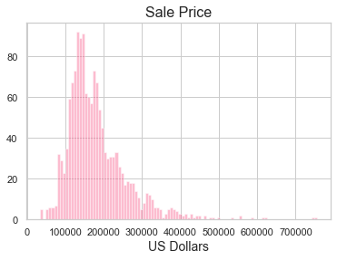

```python
sns.set(style="whitegrid")
sns.distplot(df['SalePrice'], kde=False, color='#F85888', bins=100)
plt.title('Sale Price', fontsize=16)
plt.xlabel('US Dollars', fontsize=14)
```

### Kernel Density Estimation Plot of Sale Price

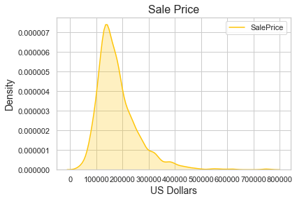

```python
sns.set(style="whitegrid")
sns.kdeplot(df['SalePrice'], color='#fec508', shade=True)
plt.title('Sale Price', fontsize=16)
plt.xlabel('US Dollars', fontsize=14)
plt.ylabel('Density', fontsize=14)
```

### Outlier Analysis

From the boxplot below, we can confirm that most of the Sale Price values fall within a certain range but there are some values that clearly lie outside of the normal distribution. Based upon the dataset, this probably accounts for properties with an abnormally high sale price.

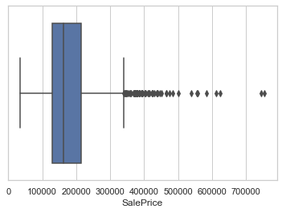

```python
sns.set(style="whitegrid")
ax = sns.boxplot(x=df['SalePrice'])
```

### Correlation vs Association

The main question we seek to answer is which individual feature has the most impact on the sales price? To me, the best way to measure that is to examine the relationship between the features and the sales price.

Pandas .corr() function is a very convenient way to find pairwise correlation of the columns within the dataframe by creating a correlation matrix. Ultimately, I want to perform feature reduction by eliminating columns that are highly correlated to each other because the information they provide is redundant. The only caveat is that this function excludes nonnumerical data.

I used seaborn to create a heatmap that shows the correlation values between features. This map also shows whether the feature negatively or positively correlates with the sales price which can tell us some things about the data. I don't see any features with a significant negative effect on the price.

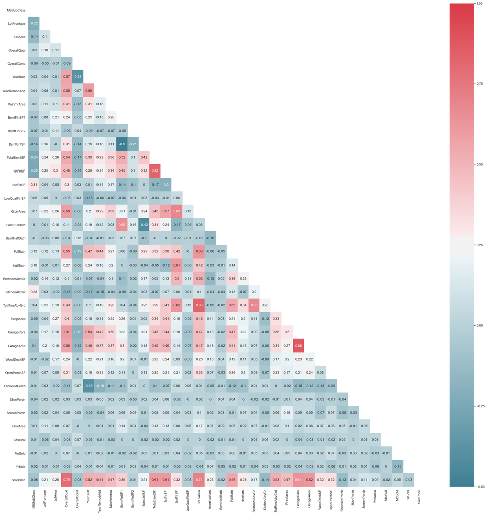

```python
corr = df.corr().round(2)
plt.figure(figsize=(30,30))
# Generate a mask for the upper triangle
mask = np.zeros_like(corr, dtype=np.bool)
mask[np.triu_indices_from(mask)] = True
cmap = sns.diverging_palette(220, 10, as_cmap=True)
sns.heatmap(corr, annot=True, mask=mask,linewidths=0, vmin=-.5, cmap=cmap)
```

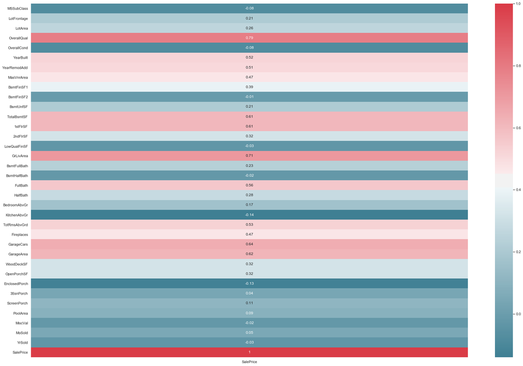

```python
f, ax = plt.subplots(figsize=(30,20))
cmap = sns.diverging_palette(220, 10, as_cmap=True)
sns.heatmap(corr[['SalePrice']], cmap=cmap, annot=True)
```

```python
#Correlation with output variable
cor_target = abs(corr["SalePrice"])

#Selecting highly correlated features
relevant_features = cor_target[cor_target>0.5]
relevant_features
```

```
OverallQual     0.79
YearBuilt       0.52
YearRemodAdd    0.51
TotalBsmtSF     0.61
1stFlrSF        0.61
GrLivArea       0.71
FullBath        0.56
TotRmsAbvGrd    0.53
GarageCars      0.64
GarageArea      0.62
SalePrice       1.00
Name: SalePrice, dtype: float64
```

```python
new_corr = new_corr[abs(corr["SalePrice"])>0.5].T
new_corr[["SalePrice"]]
```

|  | SalePrice |
| --- | --- |
| OverallQual | 0.79 |
| YearBuilt | 0.52 |
| YearRemodAdd | 0.51 |
| TotalBsmtSF | 0.61 |
| 1stFlrSF | 0.61 |
| GrLivArea | 0.71 |
| FullBath | 0.56 |
| TotRmsAbvGrd | 0.53 |
| GarageCars | 0.64 |
| GarageArea | 0.62 |
| SalePrice | 1.00 |

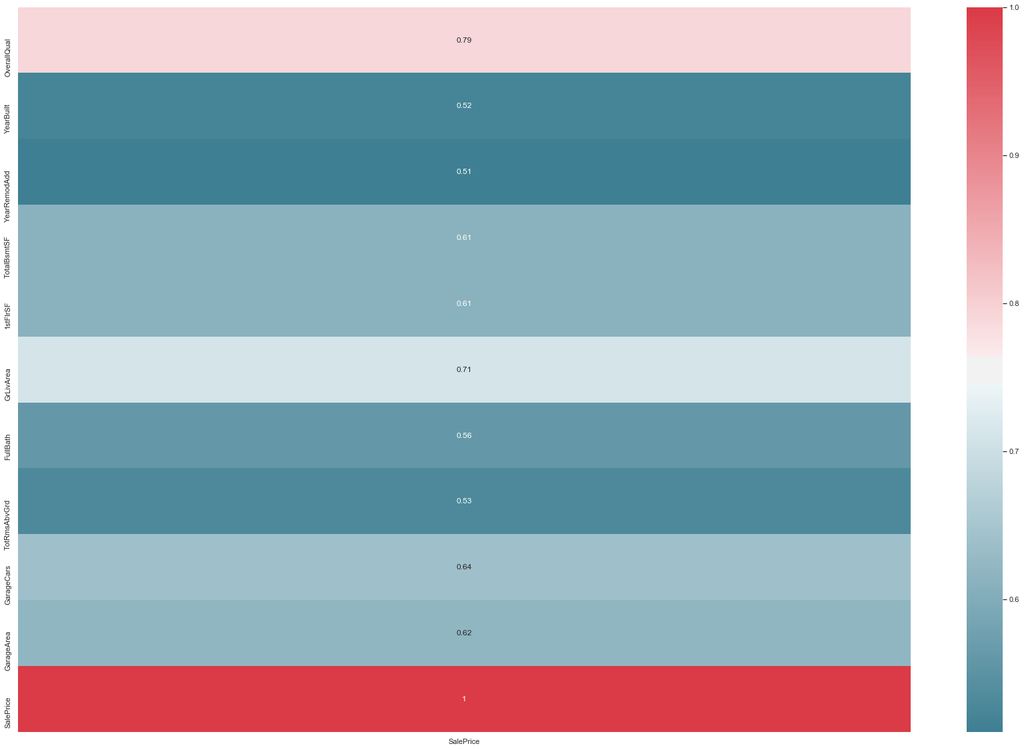

```python
f, ax = plt.subplots(figsize=(30,20))
cmap = sns.diverging_palette(220, 10, as_cmap=True)
sns.heatmap(new_corr[['SalePrice']], cmap=cmap, annot=True)
```

### Feature Selection

```python
from sklearn.ensemble import RandomForestClassifier
from sklearn.model_selection import train_test_split
from sklearn.linear_model import LogisticRegression
from sklearn.feature_selection import SelectFromModel, RFE
from sklearn.metrics import accuracy_score
from sklearn.preprocessing import OneHotEncoder, LabelEncoder, StandardScaler
```

The main question we seek to answer is **which individual feature best describes the sales price?** To me, the best way to measure that is to examine the relationship between the features and the sales price. In order to include our categorical data, we will require an alternative method for finding the *association* between these features and the sale price.

*shoutout to Hugo Ferreira for unblocking me with this awesome class found [here](https://medium.com/hugo-ferreiras-blog/dealing-with-categorical-features-in-machine-learning-1bb70f07262d).*

```python
class MultiColumnLabelEncoder:

    def __init__(self, columns = None):
        self.columns = columns # list of column to encode
    def fit(self, X, y=None):
        return self
    def transform(self, X):
        '''
        Transforms specified columns of X in self.columns with LabelEncoder().
        '''
        output = X.copy()

        if self.columns is not None:
            for col in self.columns:
                output[col] = LabelEncoder().fit_transform(output[col])
        else:
            for col_name, col in output.iteritems(): #iterates over key val pairs
                output[col_name] = LabelEncoder().fit_transform(col)

        return output

    def fit_transform(self, X, y=None):
        return self.fit(X, y).transform(X)
```

```python
X = df.drop(columns='SalePrice')
y = df['SalePrice'].astype(int).copy()
X_train, X_test, y_train, y_test = train_test_split(X, y, test_size=0.25, random_state=0)
```

```python
enc = MultiColumnLabelEncoder()
X_train_enc = enc.fit_transform(X_train)
X_train_enc.head()
```

|  | MSZoning | Street | LotShape | LandContour | Utilities | LotConfig | LandSlope | Neighborhood | Condition1 | Condition2 | BldgType | HouseStyle | OverallQual | YearBuilt | YearRemodAdd | RoofStyle | RoofMatl | Exterior1st | Exterior2nd | MasVnrType | ExterQual | ExterCond | Foundation | BsmtQual | BsmtCond | BsmtExposure | BsmtFinType1 | BsmtFinType2 | TotalBsmtSF | … |
| --- | --- | --- | --- | --- | --- | --- | --- | --- | --- | --- | --- | --- | --- | --- | --- | --- | --- | --- | --- | --- | --- | --- | --- | --- | --- | --- | --- | --- | --- | --- |
| 1292 | 4 | 1 | 3 | 3 | 0 | 0 | 0 | 17 | 2 | 2 | 0 | 5 | 4 | 5 | 15 | 1 | 0 | 13 | 14 | 3 | 3 | 4 | 4 | 4 | 4 | 4 | 6 | 6 | 227 | … |
| 1018 | 3 | 1 | 0 | 3 | 0 | 2 | 0 | 8 | 2 | 2 | 0 | 7 | 6 | 88 | 42 | 1 | 0 | 6 | 6 | 1 | 2 | 4 | 2 | 2 | 4 | 4 | 6 | 6 | 6 | … |
| 1213 | 3 | 1 | 0 | 3 | 0 | 1 | 0 | 19 | 2 | 2 | 0 | 7 | 3 | 62 | 51 | 1 | 0 | 12 | 13 | 3 | 3 | 2 | 1 | 4 | 1 | 0 | 3 | 6 | 44 | … |
| 1430 | 3 | 1 | 2 | 3 | 0 | 4 | 0 | 8 | 6 | 2 | 0 | 5 | 4 | 102 | 55 | 1 | 0 | 12 | 13 | 3 | 2 | 4 | 2 | 2 | 1 | 0 | 6 | 6 | 84 | … |
| 810 | 3 | 1 | 3 | 3 | 0 | 4 | 0 | 14 | 2 | 2 | 0 | 2 | 5 | 71 | 49 | 3 | 0 | 6 | 6 | 1 | 3 | 4 | 1 | 4 | 4 | 4 | 1 | 4 | 250 | … |

```python
one_hot_enc = OneHotEncoder(sparse=False, handle_unknown='ignore')
X_train_one_h = one_hot_enc.fit_transform(X_train_enc)
X_train_one_h
```

```
array([[0., 0., 0., ..., 0., 1., 0.],
       [0., 0., 0., ..., 0., 1., 0.],
       [0., 0., 0., ..., 0., 1., 0.],
       ...,
       [0., 0., 0., ..., 0., 1., 0.],
       [0., 0., 0., ..., 0., 1., 0.],
       [0., 0., 0., ..., 0., 1., 0.]])
```

```python
X_train_one_h.shape
```

```
(1095, 2885)
```

```python
X_test_enc = enc.transform(X_test)
X_test_one_h = one_hot_enc.transform(X_test_enc)
X_test_one_h
```

```
array([[0., 0., 0., ..., 0., 0., 0.],
       [0., 0., 0., ..., 0., 1., 0.],
       [0., 0., 0., ..., 0., 1., 0.],
       ...,
       [0., 0., 0., ..., 0., 1., 0.],
       [0., 0., 0., ..., 0., 0., 1.],
       [0., 0., 0., ..., 0., 1., 0.]])
```

```python
s = StandardScaler()
sc_X_train = s.fit_transform(X_train_one_h)
sc_X_test = s.transform(X_test_one_h)
```

```python
features = df.columns.tolist()
clf = RandomForestClassifier(class_weight=None, criterion='gini', n_estimators=300,
 max_depth=3, max_features='auto', max_leaf_nodes=None, n_jobs=-1, random_state=None)
clf.fit(sc_X_train, y_train)
clf.score(sc_X_test, y_test)
```

```
0.010958904109589041
```

```python
features = df.columns.tolist()
for feature in zip(features, clf.feature_importances_):
    print(feature)
```

```
('MSZoning', 0.0017368807720815889)
('Street', 0.0)
('LotShape', 0.0)
('LandContour', 0.0012562769449644946)
('Utilities', 0.000643698884706875)
('LotConfig', 0.0)
('LandSlope', 0.0)
('Neighborhood', 0.0011777384648638234)
('Condition1', 0.000405400743797141)
('Condition2', 0.0)
('BldgType', 0.0010517254585143312)
('HouseStyle', 0.0)
('OverallQual', 0.0)
('YearBuilt', 0.0)
('YearRemodAdd', 0.0)
('RoofStyle', 0.0)
('RoofMatl', 0.0011117351962272493)
('Exterior1st', 0.0003970901758462368)
('Exterior2nd', 0.0)
('MasVnrType', 0.0)
('ExterQual', 0.0013748961662353747)
('ExterCond', 0.0014541094987117874)
('Foundation', 0.0005848110105191333)
('BsmtQual', 0.00039898731152294633)
('BsmtCond', 0.0006308693119657714)
('BsmtExposure', 0.0)
('BsmtFinType1', 0.0)
('BsmtFinType2', 0.0)
('TotalBsmtSF', 0.0014798166835883792)
('Heating', 0.0006285513283776294)
('HeatingQC', 0.001995683995563113)
('CentralAir', 0.0)
('Electrical', 0.0)
('1stFlrSF', 0.0)
('GrLivArea', 0.0)
('FullBath', 0.0)
('KitchenQual', 0.0)
('TotRmsAbvGrd', 0.0010989912423352713)
('Functional', 0.0)
('FireplaceQu', 0.0017088113425799505)
('GarageType', 0.0009559409460530525)
('GarageYrBlt', 0.0)
('GarageFinish', 0.0004113195948200506)
('GarageCars', 0.0)
('GarageArea', 0.0)
('GarageQual', 0.0)
('GarageCond', 0.0)
('PavedDrive', 0.0)
('SaleType', 0.0007732702646190033)
('SaleCondition', 0.0)
('SalePrice', 0.0)
```

```python
ypred = clf.predict(sc_X_test)
```

```python
errors = abs(ypred - y_test)
print('Metrics for Random Forest Trained on Original Data')
print('Average absolute error:', round(np.mean(errors), 2), 'degrees.')
```

```
Metrics for Random Forest Trained on Original Data
Average absolute error: 58510.02 degrees.
```

```python
mape = 100 * (errors / y_test)
# Calculate and display accuracy
accuracy = 100 - np.mean(mape)
print('Accuracy:', round(accuracy, 2), '%.')
```

```
Accuracy: 72.4 %.
```